# Practice Code: Day 6

Author

Constantin Manuel Bosancianu

Published

August 5, 2019

# 1 Introduction

We will continue with the CSES data set from Friday, though we will only take wave 3 to work with. Because of the computationally demanding nature of the estimation for GLMMs, it makes more sense to practice on a 2-level model, rather than try for a full 3-level specification.

Unlike Friday, our focus will no longer be on political efficacy, but rather on turnout: whether an individual voted in the previous election, or intends to vote in the upcoming one (1 = yes; 0 = no).

```r
library(pacman)
p_load(tidyverse, ggeffects, texreg, arm, broom.mixed,
       ggthemes, broom, knitr, kableExtra, magrittr)
```

We also define here the standard centering function we’ve been using so far.

```r
fun_two_SD <- function(x) {
        (x - mean(x, na.rm = TRUE)) / (2 * sd(x, na.rm = TRUE))
}
```

# 2 Data input and preparation

```r
df_cses <- readRDS("../02-data/02-CSES14-subset.rds")

df_cses %<>%
    filter(wave == 3) %>%
    dplyr::select(country, year, age, male, educat,
                  unmemb, income, urban, polinfo, turnout,
                  corr_ind, div_ctrl, gini10, mdmh, comp) %>%
    na.omit()

df_cses %<>%
    mutate(inc1 = if_else(income == 0, 1, 0),
           inc2 = if_else(income == 1, 1, 0),
           inc3 = if_else(income == 2, 1, 0),
           inc4 = if_else(income == 3, 1, 0),
           inc5 = if_else(income == 4, 1, 0),
           info_high = case_when(polinfo %in% c(0,1) ~ 0,
                                 polinfo %in% c(2,3) ~ 1),
           urban2 = case_when(urban %in% c(0,1) ~ 0,
                              urban %in% c(2,3) ~ 1),)
```

We are now left with only 47451 respondents, from 30 countries.

A host of data checks could be performed. An important one is an assessment of the distribution of the outcome variable across the different groups.

```r
df_cses %>%
    group_by(country) %>%
    summarise(Abstained = prop.table(table(turnout))[1],
              Voted = prop.table(table(turnout))[2]) %>%
    kable(caption = "Turnout distribution in the sample countries",
          caption.above = TRUE,
          digits = 2) %>%
    kable_styling(full_width = TRUE)
```

Turnout distribution in the sample countries

| country | Abstained | Voted |
| --- | --- | --- |
| Australia | 0.01 | 0.99 |
| Austria | 0.14 | 0.86 |
| Belarus | 0.31 | 0.69 |
| Brazil | 0.08 | 0.92 |
| Croatia | 0.18 | 0.82 |
| Czech Republic | 0.26 | 0.74 |
| Denmark | 0.02 | 0.98 |
| Estonia | 0.18 | 0.82 |
| Finland | 0.15 | 0.85 |
| France | 0.18 | 0.82 |
| Germany | 0.13 | 0.87 |
| Greece | 0.11 | 0.89 |
| Iceland | 0.07 | 0.93 |
| Ireland | 0.10 | 0.90 |
| Israel | 0.19 | 0.81 |
| Mexico | 0.19 | 0.81 |
| Netherlands | 0.07 | 0.93 |
| New Zealand | 0.03 | 0.97 |
| Norway | 0.08 | 0.92 |
| Peru | 0.05 | 0.95 |
| Poland | 0.38 | 0.62 |
| Portugal | 0.25 | 0.75 |
| Slovakia | 0.21 | 0.79 |
| Slovenia | 0.20 | 0.80 |
| South Korea | 0.34 | 0.66 |
| Sweden | 0.08 | 0.92 |
| Switzerland | 0.25 | 0.75 |
| Thailand | 0.02 | 0.98 |
| Turkey | 0.06 | 0.94 |
| Uruguay | 1.00 | NA |

It’s not clear what’s happening in Uruguay - I have seen instances like this before (an early 2000s Russia sample that was included in the World Values Surveys). It is likely a case of mistaken coding, and I would opt to eliminate it.

```r
df_cses %<>%
    filter(!(country == "Uruguay"))
```

The other standard checks for the predictors, as you would do in the course of a normal model estimation procedure can be done here as well.

# 3 Centering

Do the needed centering for the predictors beforehand.

```r
df_cses %<>%
    group_by(country) %>%
    mutate(ageCWC = fun_two_SD(age),
           maleCWC = fun_two_SD(male),
           educCWC = fun_two_SD(educat),
           membCWC = fun_two_SD(unmemb),
           infoCWC = fun_two_SD(info_high),
           urbanCWC = fun_two_SD(urban2),
           inc1CWC = fun_two_SD(inc1),
           inc2CWC = fun_two_SD(inc2),
           inc3CWC = fun_two_SD(inc3),
           inc4CWC = fun_two_SD(inc4),
           inc5CWC = fun_two_SD(inc5)) %>%
    dplyr::select(-info_high, -urban2) %>%
    na.omit()
```

```r
df_agg <- df_cses %>%
    group_by(country) %>%
    summarise(corr_ind = mean(corr_ind, na.rm = TRUE),
              gini10 = mean(gini10, na.rm = TRUE),
              comp = mean(comp, na.rm = TRUE)) %>%
    mutate(corrCGM = fun_two_SD(corr_ind),
           gini10CGM = fun_two_SD(gini10),
           compCGM = fun_two_SD(comp)) %>%
    dplyr::select(-corr_ind, -gini10, -comp)

df_cses <- left_join(df_cses, df_agg, by = c("country"))
rm(df_agg)
```

# 4 Null model

As with all of the previous attempts at running mixed-effects models, we can start with a null model here as well. The function to estimate a GLMM is `glmer()`.[^1]

<sup>1</sup> Notice how similar it is to `glm()` in terms of having to specify a link function for the outcome. The estimation procedure, though, is considerably more intensive than in the case of LMMs.

```r
mlm.0 <- glmer(turnout ~ 1 + (1 | country),
               data = df_cses,
               family = binomial(link = "logit"))
summary(mlm.0)
```

```
Generalized linear mixed model fit by maximum likelihood (Laplace
  Approximation) [glmerMod]
 Family: binomial  ( logit )
Formula: turnout ~ 1 + (1 | country)
   Data: df_cses

     AIC      BIC   logLik deviance df.resid
 33956.4  33973.7 -16976.2  33952.4    44045

Scaled residuals:
    Min      1Q  Median      3Q     Max
-9.6097  0.2316  0.2979  0.4707  0.7796

Random effects:
 Groups  Name        Variance Std.Dev.
 country (Intercept) 1.034    1.017
Number of obs: 44047, groups:  country, 26

Fixed effects:
            Estimate Std. Error z value Pr(>|z|)
(Intercept)   2.0891     0.1992   10.49   <2e-16 ***
---
Signif. codes:  0 '***' 0.001 '**' 0.01 '*' 0.05 '.' 0.1 ' ' 1
```

<sup>2</sup> Residual error variance is fixed at $\pi^{2/3}$.

# 5 Level-1 model

Start by gradually adding predictors at the individual-level, until you’re satisfied that you’ve obtained a correct specification at this level.

## 5.1 Initial specification

```r
mlm.1 <- glmer(turnout ~ 1 + ageCWC + maleCWC + educCWC +
                   membCWC + inc2CWC + inc3CWC + inc4CWC + inc5CWC +
                   infoCWC + urbanCWC + (1 | country),
               data = df_cses,
               family = binomial(link = "logit"))
summary(mlm.1)
```

```
Generalized linear mixed model fit by maximum likelihood (Laplace
  Approximation) [glmerMod]
 Family: binomial  ( logit )
Formula: turnout ~ 1 + ageCWC + maleCWC + educCWC + membCWC + inc2CWC +
    inc3CWC + inc4CWC + inc5CWC + infoCWC + urbanCWC + (1 | country)
   Data: df_cses

     AIC      BIC   logLik deviance df.resid
 32076.9  32181.2 -16026.4  32052.9    44035

Scaled residuals:
     Min       1Q   Median       3Q      Max
-15.6005   0.1615   0.2929   0.4382   1.7518

Random effects:
 Groups  Name        Variance Std.Dev.
 country (Intercept) 1.102    1.05
Number of obs: 44047, groups:  country, 26

Fixed effects:
             Estimate Std. Error z value Pr(>|z|)
(Intercept)  2.224073   0.207529  10.717  < 2e-16 ***
ageCWC       0.783476   0.030015  26.103  < 2e-16 ***
maleCWC     -0.018311   0.029023  -0.631  0.52809
educCWC      0.523548   0.033836  15.473  < 2e-16 ***
membCWC      0.262065   0.032606   8.037 9.18e-16 ***
inc2CWC      0.092107   0.034010   2.708  0.00676 **
inc3CWC      0.212699   0.035233   6.037 1.57e-09 ***
inc4CWC      0.316124   0.036469   8.668  < 2e-16 ***
inc5CWC      0.443730   0.039952  11.106  < 2e-16 ***
infoCWC      0.612169   0.029170  20.986  < 2e-16 ***
urbanCWC    -0.002751   0.028847  -0.095  0.92404
---
Signif. codes:  0 '***' 0.001 '**' 0.01 '*' 0.05 '.' 0.1 ' ' 1

Correlation of Fixed Effects:
         (Intr) ageCWC malCWC edcCWC mmbCWC in2CWC in3CWC in4CWC in5CWC infCWC
ageCWC    0.019
maleCWC   0.000  0.031
educCWC   0.013  0.240  0.021
membCWC   0.006 -0.032 -0.044 -0.020
inc2CWC   0.001  0.013 -0.033 -0.076 -0.043
inc3CWC   0.003  0.061 -0.042 -0.129 -0.050  0.483
inc4CWC   0.005  0.082 -0.047 -0.166 -0.054  0.453  0.456
inc5CWC   0.008  0.084 -0.058 -0.236 -0.059  0.423  0.433  0.430
infoCWC   0.014 -0.054 -0.122 -0.149  0.003 -0.030 -0.046 -0.054 -0.077
urbanCWC -0.001 -0.012  0.015 -0.134 -0.010 -0.005 -0.008 -0.022 -0.046 -0.016
```

My approach has recently been to keep predictors in the model specification as long as there is theory suggesting they ought to have an impact on the outcome, irrespective of whether they are significant or not. However, if there is no theory justifying their inclusion, and they are not statistically significant, then I would normally exclude them from the model specification.

```r
mlm.1 <- glmer(turnout ~ 1 + ageCWC + maleCWC + educCWC +
                   membCWC + inc2CWC + inc3CWC + inc4CWC + inc5CWC +
                   infoCWC + (1 | country),
               data = df_cses,
               family = binomial(link = "logit"))
summary(mlm.1)
```

```
Generalized linear mixed model fit by maximum likelihood (Laplace
  Approximation) [glmerMod]
 Family: binomial  ( logit )
Formula: turnout ~ 1 + ageCWC + maleCWC + educCWC + membCWC + inc2CWC +
    inc3CWC + inc4CWC + inc5CWC + infoCWC + (1 | country)
   Data: df_cses

     AIC      BIC   logLik deviance df.resid
 32074.9  32170.5 -16026.4  32052.9    44036

Scaled residuals:
     Min       1Q   Median       3Q      Max
-15.6084   0.1615   0.2930   0.4381   1.7524

Random effects:
 Groups  Name        Variance Std.Dev.
 country (Intercept) 1.102    1.05
Number of obs: 44047, groups:  country, 26

Fixed effects:
            Estimate Std. Error z value Pr(>|z|)
(Intercept)  2.22406    0.20738  10.725  < 2e-16 ***
ageCWC       0.78344    0.03001  26.103  < 2e-16 ***
maleCWC     -0.01827    0.02902  -0.630  0.52900
educCWC      0.52312    0.03353  15.601  < 2e-16 ***
membCWC      0.26203    0.03260   8.037 9.20e-16 ***
inc2CWC      0.09209    0.03401   2.708  0.00677 **
inc3CWC      0.21267    0.03523   6.036 1.58e-09 ***
inc4CWC      0.31605    0.03646   8.668  < 2e-16 ***
inc5CWC      0.44355    0.03991  11.114  < 2e-16 ***
infoCWC      0.61212    0.02917  20.988  < 2e-16 ***
---
Signif. codes:  0 '***' 0.001 '**' 0.01 '*' 0.05 '.' 0.1 ' ' 1

Correlation of Fixed Effects:
        (Intr) ageCWC malCWC edcCWC mmbCWC in2CWC in3CWC in4CWC in5CWC
ageCWC   0.019
maleCWC  0.000  0.031
educCWC  0.013  0.240  0.023
membCWC  0.006 -0.032 -0.044 -0.022
inc2CWC  0.001  0.013 -0.032 -0.078 -0.043
inc3CWC  0.003  0.061 -0.042 -0.131 -0.050  0.483
inc4CWC  0.005  0.082 -0.046 -0.171 -0.055  0.453  0.456
inc5CWC  0.008  0.084 -0.057 -0.245 -0.059  0.424  0.433  0.429
infoCWC  0.014 -0.054 -0.122 -0.152  0.003 -0.030 -0.046 -0.055 -0.078
```

By default the coefficients are depicted in log-odds format. You can easily get to odds by doing the converse transformation.

```r
exp(fixef(mlm.1))
```

```
(Intercept)      ageCWC     maleCWC     educCWC     membCWC     inc2CWC
  9.2447483   2.1889936   0.9818973   1.6872790   1.2995718   1.0964631
    inc3CWC     inc4CWC     inc5CWC     infoCWC
  1.2369767   1.3716969   1.5582361   1.8443445
```

My advice is to try and plot the effects of these variables, using the same functions we have used for LMMs.

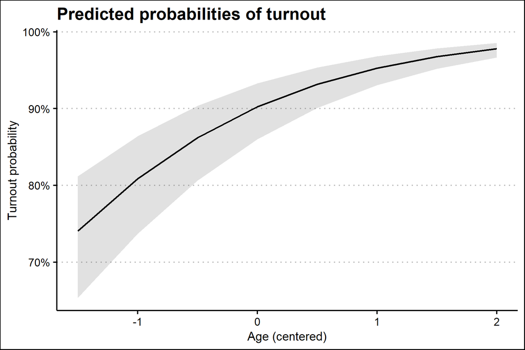

```r
dat1 <- ggpredict(mlm.1,
                  terms = "ageCWC",
                  ci.lvl = 0.95,
                  type = "fe")
plot(dat1) +
    theme_clean() +
    labs(x = "Age (centered)",
         y = "Turnout probability")
```

```r
rm(dat1)
```

## 5.2 Model fit

We also get the usual model fit measures.

```r
logLik(mlm.1)
```

```
'log Lik.' -16026.44 (df=11)
```

```r
AIC(mlm.1)
```

```
[1] 32074.88
```

```r
BIC(mlm.1)
```

```
[1] 32170.5
```

Given that the outcome is 0 or 1, we can actually get a different type of assessment of model fit, by looking at proportion of cases correctly predicted.

```r
df_cses$fitted.1 <- fitted(mlm.1)

# Convert probabilities to actual responses (0 or 1)
df_cses %<>%
    mutate(resp.1 = if_else(fitted.1 > 0.5, 1, 0))
```

How are we doing in terms of correct classification?

```r
prop.table(table(df_cses$turnout,
                 df_cses$resp.1),
           1) # show the table in a format where rows sum up to 1
```

```
             0          1
  0 0.08067457 0.91932543
  1 0.00963566 0.99036434
```

It’s a bit hard to tell how well we’re doing in absolute terms, but we can use as a point of reference the null model.

```r
df_cses$fitted.0 <- fitted(mlm.0)

df_cses %<>%
    mutate(resp.0 = if_else(fitted.0 > 0.5, 1, 0))

prop.table(table(df_cses$turnout,
                 df_cses$resp.0),
           1)
```

```
    1
  0 1
  1 1
```

You can get assessments like this for separate groups in your sample.

```r
prop.table(table(df_cses$turnout[df_cses$country == "Portugal"],
                 df_cses$resp.1[df_cses$country == "Portugal"]),
           1)
```

```
              0           1
  0 0.010256410 0.989743590
  1 0.005263158 0.994736842
```

# 6 Level-2 model

Estimating this will take a fair amount of time, at least in relative terms, when you compare it to a comparable specification in terms of complexity in the case of a LMM.

```r
mlm.2 <- glmer(turnout ~ 1 + ageCWC + maleCWC + educCWC +
                   membCWC + inc2CWC + inc3CWC + inc4CWC + inc5CWC +
                   infoCWC + corrCGM + gini10CGM + compCGM +
                   (1 | country),
               data = df_cses,
               family = binomial(link = "logit"))
summary(mlm.2)
```

```
Generalized linear mixed model fit by maximum likelihood (Laplace
  Approximation) [glmerMod]
 Family: binomial  ( logit )
Formula: turnout ~ 1 + ageCWC + maleCWC + educCWC + membCWC + inc2CWC +
    inc3CWC + inc4CWC + inc5CWC + infoCWC + corrCGM + gini10CGM +
    compCGM + (1 | country)
   Data: df_cses

     AIC      BIC   logLik deviance df.resid
 32065.7  32187.4 -16018.8  32037.7    44033

Scaled residuals:
     Min       1Q   Median       3Q      Max
-15.3166   0.1625   0.2929   0.4380   1.7520

Random effects:
 Groups  Name        Variance Std.Dev.
 country (Intercept) 0.6097   0.7809
Number of obs: 44047, groups:  country, 26

Fixed effects:
            Estimate Std. Error z value Pr(>|z|)
(Intercept)  2.22590    0.15516  14.346  < 2e-16 ***
ageCWC       0.78340    0.03001  26.102  < 2e-16 ***
maleCWC     -0.01830    0.02902  -0.631  0.52834
educCWC      0.52299    0.03353  15.598  < 2e-16 ***
membCWC      0.26205    0.03260   8.038 9.13e-16 ***
inc2CWC      0.09219    0.03401   2.711  0.00671 **
inc3CWC      0.21289    0.03523   6.042 1.52e-09 ***
inc4CWC      0.31625    0.03646   8.673  < 2e-16 ***
inc5CWC      0.44374    0.03991  11.119  < 2e-16 ***
infoCWC      0.61211    0.02917  20.986  < 2e-16 ***
corrCGM     -1.09979    0.46501  -2.365  0.01802 *
gini10CGM   -0.88748    0.52558  -1.689  0.09130 .
compCGM      2.45459    0.56306   4.359 1.30e-05 ***
---
Signif. codes:  0 '***' 0.001 '**' 0.01 '*' 0.05 '.' 0.1 ' ' 1
```

Predictions will work equally well for L2 variables.

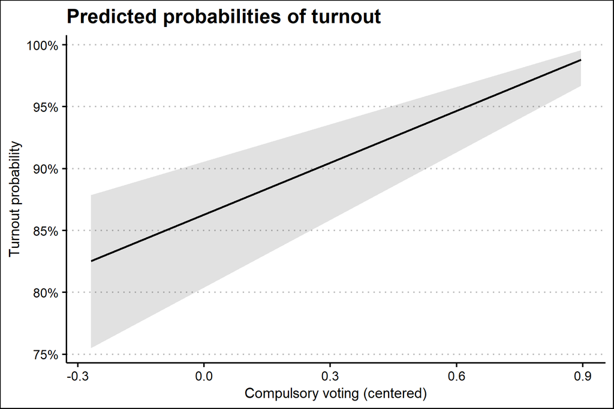

```r
dat2 <- ggpredict(mlm.2,
                  terms = "compCGM",
                  ci.lvl = 0.95,
                  type = "fe")
plot(dat2) +
    theme_clean() +
    labs(x = "Compulsory voting (centered)",
         y = "Turnout probability")
```

```r
rm(dat2)
```